# Midpoint Deliverable

## Introduction of Domain/Data set

The acute nature of infectious disease often draws our attention because of the imminent pain and suffering they bring to millions around the globe, as seen by the current Coronavirus pandemic. However, the physical and mental impact of non-infectious chronic diseases can also be overwhelming to patients, and should not be ignored. We are interested in analyzing data on how different non-infectious chronic diseases can affect the lives of people all around the world. In this example, we are focusing on a neoplasm data set. This data was taken using the GHDx data selecting tool for the 2017 IHME Global Burden of Disease Study and was generated via compilation of various neoplasm-related publication data sets, mortality, and other health metric data released by individual countries.

## Summary

We summarized some important information about the neoplasm data set we selected. There are 155988 neoplasm cases in total. In order to better measure the data presented, we selected ten attributes: measure, location, sex, age, cause, metric, year, val, upper, lower (metric: how we measured the val (average), lower (lower bound), and upper (upper bound)). We also measured 3 different types of neoplasm health-related consequences: YLLs (Years of Life Lost), Deaths, DALYs (Disability-Adjusted Life Years). Our data set began recording neoplasm cases in 1990, and goes all the way up to 2017. Moreover, neoplasms have occurred to Both genders (that this data set accounts for).

## Aggregate Table of Interest

We wanted to see how neoplasms affected each location in our data set. In this table, we included four columns: location (sorted in alphabetical order), average YLLs (Years of Life Lost), average Deaths, and average DALYs (Disability-Adjusted Life Years) per country by percent from 1990 to 2017. We found that there is a direct correlation between a country’s SDI and the rate of YYLs, Deaths, and DALYs increasing.

| Location | Years of Life Lost | Deaths | Disability-Adjusted Life Years |
| --- | --- | --- | --- |
| Aceh | 0.0706904 | 0.0884675 | 0.0531021 |
| Acre | 0.0787734 | 0.1149222 | 0.0525877 |
| Afghanistan | 0.0318796 | 0.0549238 | 0.0272946 |
| Africa | 0.0294296 | 0.0520490 | 0.0251927 |
| African Region | 0.0270638 | 0.0492346 | 0.0235202 |
| African Union | 0.0288253 | 0.0512784 | 0.0247650 |
| Aguascalientes | 0.1156987 | 0.1397707 | 0.0738953 |
| Aichi | 0.3614796 | 0.3178329 | 0.1885990 |
| Akita | 0.3562223 | 0.3070272 | 0.2076608 |
| Alabama | 0.2428516 | 0.2411300 | 0.1547842 |
| Alagoas | 0.0630248 | 0.0893019 | 0.0451723 |
| Alaska | 0.2241481 | 0.2540537 | 0.1254791 |
| Albania | 0.1807884 | 0.1791408 | 0.1072166 |
| Algeria | 0.0856661 | 0.1038908 | 0.0523635 |
| AmapÃ¡ | 0.0954012 | 0.1383219 | 0.0607433 |
| Amazonas | 0.1100535 | 0.1536017 | 0.0705633 |
| America | 0.1684469 | 0.2007937 | 0.1087320 |
| American Samoa | 0.1337761 | 0.1549623 | 0.0876534 |
| Andean Latin America | 0.1112545 | 0.1563145 | 0.0762323 |
| Andorra | 0.3428502 | 0.3065924 | 0.1689592 |
| Angola | 0.0236068 | 0.0425958 | 0.0205730 |
| Antigua and Barbuda | 0.1742194 | 0.1883782 | 0.1052595 |
| ÅŒita | 0.3438199 | 0.2913167 | 0.1888989 |
| ÅŒsaka | 0.3739288 | 0.3351968 | 0.2051407 |
| Aomori | 0.3487045 | 0.3075360 | 0.2034782 |
| Argentina | 0.2112784 | 0.2185873 | 0.1359190 |
| Arizona | 0.2359741 | 0.2402070 | 0.1354265 |
| Arkansas | 0.2435957 | 0.2363777 | 0.1556435 |
| Armenia | 0.2000856 | 0.1879886 | 0.1305285 |
| Asia | 0.1055058 | 0.1393436 | 0.0760802 |

[output cut: 586 more lines]

## Charts

### Chart 1

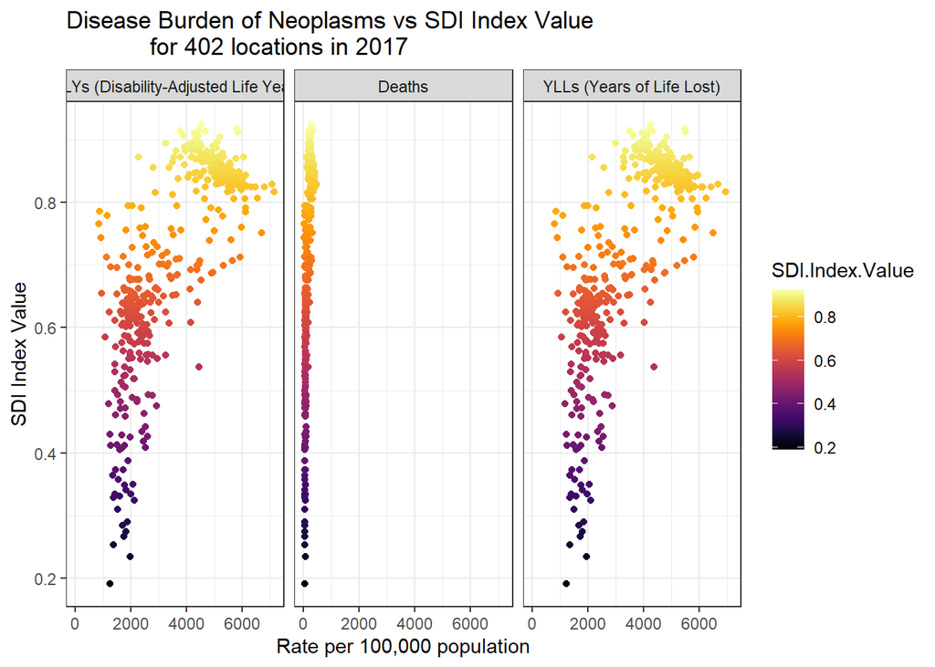

This scatter plot was intended to show the disease burden of neoplasms, including disability-adjusted life years, years of life lost, and deaths, versus SDI index value for the year of 2017. One observation we found is that the death rates are less scattered compared to the DALYs and YLLs.

### Chart 2

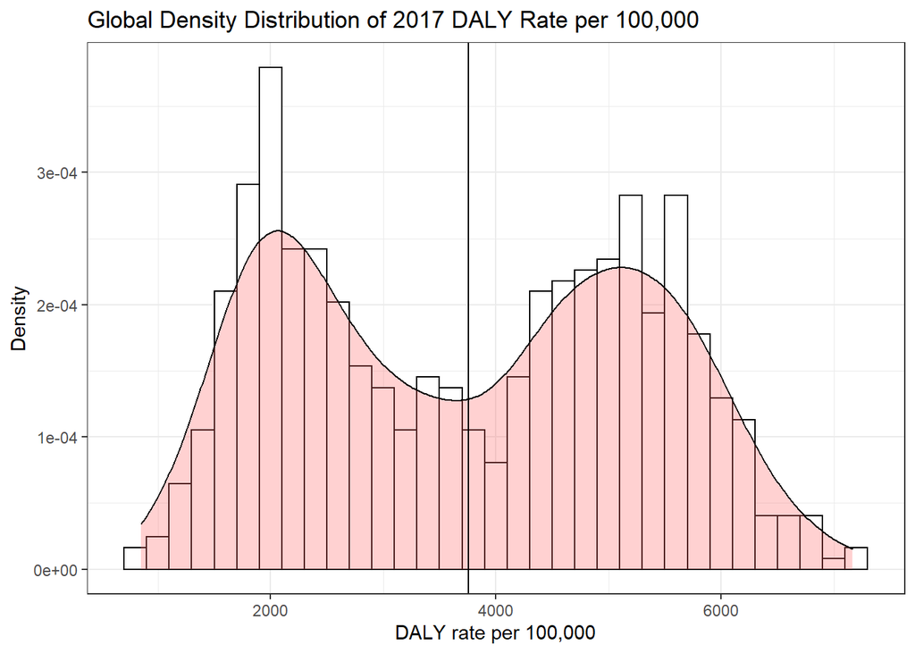

### Chart 3

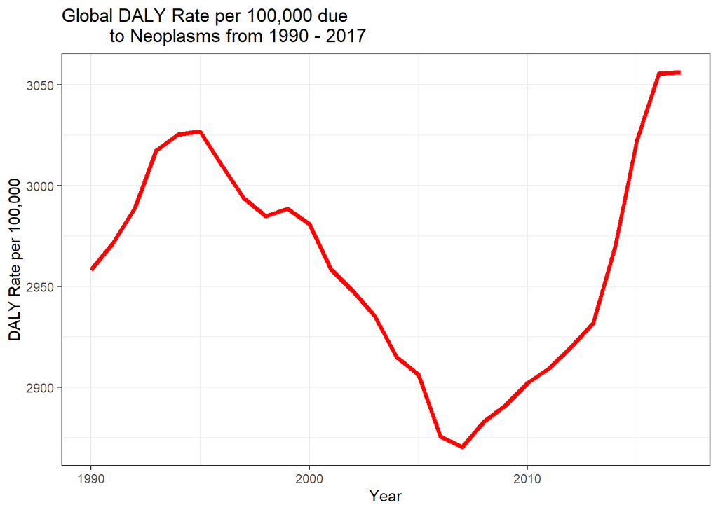